# The Taxicab Problem

11/6/2021

# Problem Statement

“Suppose you arrive in a new city and see a taxi numbered 100. How many taxis are there in this city?”[^1] Taxis are numbered 0, 1, 2, 3, …, up to the last taxi.

# A Classical Approach

You already have intuition about how to proceed. The likelihood of what you observed – taxicab #100 – depends on how many taxis there are in total. Your estimate of total taxi count should somehow elevate the likelihood of what you observed.

A classical approach: estimate a total taxi count which *maximizes* the likelihood of what you observed.[^2] An estimate of 101 follows. (Recall: numbering started at zero.) Why? Assuming the city has 101 taxicabs, the likelihood of observing taxicab #100 equals 1/101, or about 1%. Estimate any higher number of taxicabs, and this probability necessarily decreases.

However, we should be unsatisfied with this estimate! This “optimal” estimate follows from a *narrowly-defined* framework. The framework must be scrutinized. Then, a fundamental question arises: what if we simply observed an event with less-than-maximum likelihood? This feels entirely possible – our lives are full of relatively surprising events.

To robustify our estimate, we may take an alternate statistical approach.

# A Bayesian Improvement

Consider this estimation approach: let’s specify prior knowledge about total taxi count, and then update that assessment, given what we observed (taxicab #100).[^3]

Question one: how might we specify prior knowledge about total taxi count? First we’ll identify the range of possible estimates. Then, we’ll assign each possible value a weight – higher weight signifies a more probable estimate. The weights may be generated by a well-defined probability formula[^4]. Envision a few scenarios for prior knowledge[^5]:

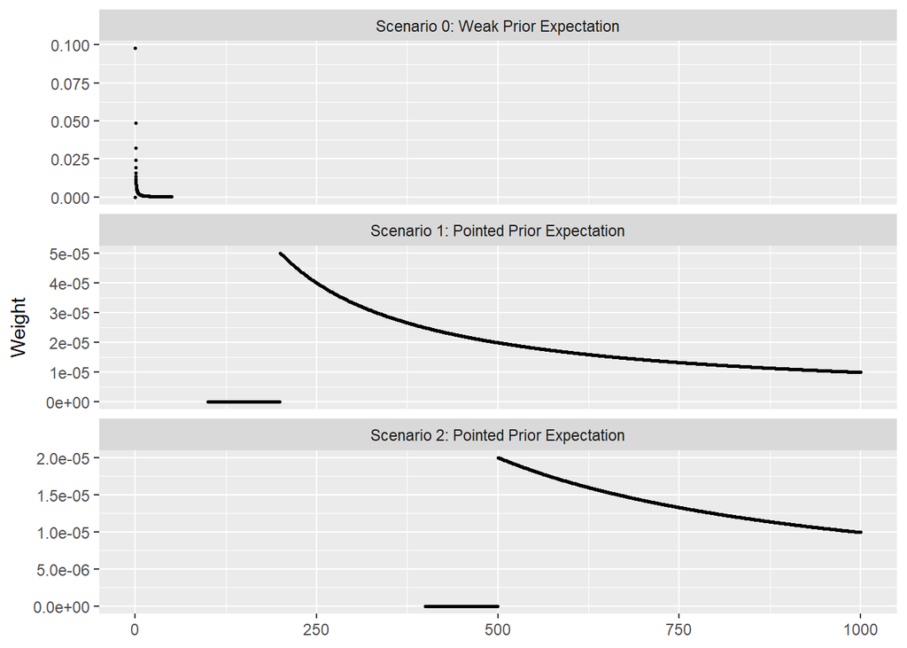

[^1]: I find this question in Kevin Murphy’s *Machine Learning: A Probabilistic Perspective*. A great read!
[^2]: “Maximum Likelihood Estimation” is a fundamental method in statistics.
[^3]: This estimation approach follows Bayes’ Theorem, another fundamental statement in statistics.
[^4]: In the lingo, probability distribution.
[^5]: These prior knowledge scenarios come from one probability distribution *family*, the Pareto. This particular family makes for simpler calculations later.